# DSC5103 statistics final project

Predicting blood donation of individuals in March 2007

Section G1;Group 04 (Members: CHO ZIN TUN, HAN YILI, SWETHA NARAYANAN, TOH PEI XUAN, ZHOU FENGYI)

Nov 2017

## 1) Introduction

This data is obtained from a mobile blood donation vehicle in Taiwan. The Blood Transfusion Service Center drives to different universities and collects blood as part of a blood drive. This data is stored at UCI Machine Learning repository. https://archive.ics.uci.edu/ml/datasets/Blood+Transfusion+Service+Center

Predictors provided are:

1. months since last donation
2. total number of donation
3. Total Volume Donated (c.c.)
4. Months since First Donation

We want to make predictions based on these characteristics to see if the person dontaes blood on March 2007.

### 1a) Data Cleansing

We start with loading and cleaning the data for training and testing

```r
datamodel=read.csv("Blood.csv")
summary(datamodel)
```

```
##        X         Months.since.Last.Donation Number.of.Donations
##  Min.   :  0.0   Min.   : 0.000             Min.   : 1.000
##  1st Qu.:183.8   1st Qu.: 2.000             1st Qu.: 2.000
##  Median :375.5   Median : 7.000             Median : 4.000
##  Mean   :374.0   Mean   : 9.439             Mean   : 5.427
##  3rd Qu.:562.5   3rd Qu.:14.000             3rd Qu.: 7.000
##  Max.   :747.0   Max.   :74.000             Max.   :50.000
##  Total.Volume.Donated..c.c.. Months.since.First.Donation
##  Min.   :  250               Min.   : 2.00
##  1st Qu.:  500               1st Qu.:16.00
##  Median : 1000               Median :28.00
##  Mean   : 1357               Mean   :34.05
##  3rd Qu.: 1750               3rd Qu.:49.25
##  Max.   :12500               Max.   :98.00
##  Made.Donation.in.March.2007
##  Min.   :0.0000
##  1st Qu.:0.0000
##  Median :0.0000
##  Mean   :0.2396
##  3rd Qu.:0.0000
##  Max.   :1.0000
```

```r
sum(is.na(datamodel[,]))
```

```
## [1] 0
```

There is no missing values in the data;

Our variable of interest “Made.Donation.In.March.2007” are binary values; 1 means the person donated blood in March 2007, while 0 means he/she did not

```r
datamodel$Made.Donation.in.March.2007=as.factor(datamodel$Made.Donation.in.March.2007)
```

### 1b) Visualisation of data

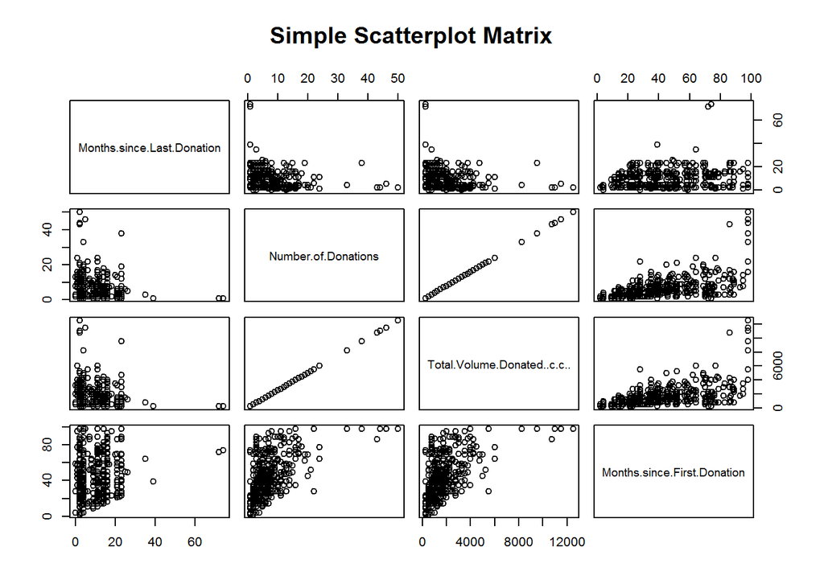

```r
library(lattice)
#Scatterplot
pairs(~Months.since.Last.Donation+Number.of.Donations+Total.Volume.Donated..c.c..+Months.since.First.Donation,data=datamodel,
      main="Simple Scatterplot Matrix")
```

```r
par(mfrow=c(2,2))
```

### Scatterplot

What is quite obvious is that the number of donations have linear relationship with the total volume donated, which is reasonable.

Between months since last donation and number of donations, these two variables, we can see that people have recently donate blood tend to have more total number of donations up till now. Equivalently, months since last donation and total volume donated have similar relationship, which means people have recently donate blood tend to have donated more volume up till now.

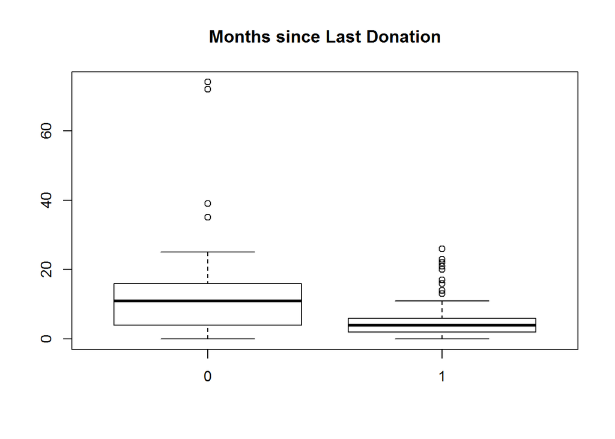

```r
#Boxplot
plot(datamodel$Made.Donation.in.March.2007,datamodel$Months.since.Last.Donation,main="Months since Last Donation")
```

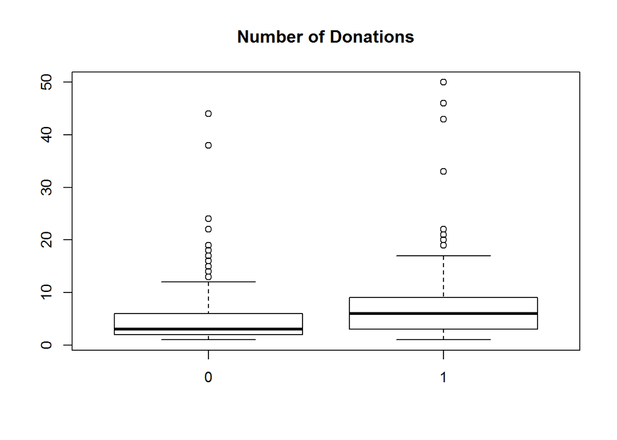

```r
plot(datamodel$Made.Donation.in.March.2007,datamodel$Number.of.Donations,main="Number of Donations")
```

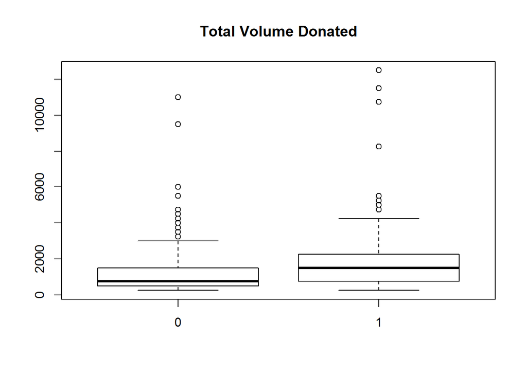

```r
plot(datamodel$Made.Donation.in.March.2007,datamodel$Total.Volume.Donated..c.c..,main="Total Volume Donated")
```

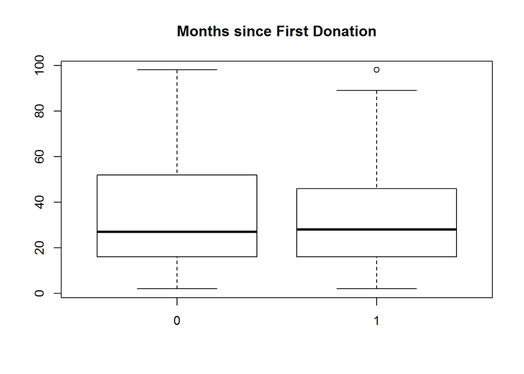

```r
plot(datamodel$Made.Donation.in.March.2007,datamodel$Months.since.First.Donation,main="Months since First Donation")
```

```r
par(mfrow=c(2,2))
```

### Boxplot

From the first graph, we can observe that people who recently( within 5 months until March 2007) came to donate blood had come on March 2007 to donate again.

The second and third graph shows that the people who have donated higher number of times and higher volume have come back to donate blood on March 2007.

From the fourth graph, it seems that people who came to donate again on March 2007 is not related with when he did his first donation.

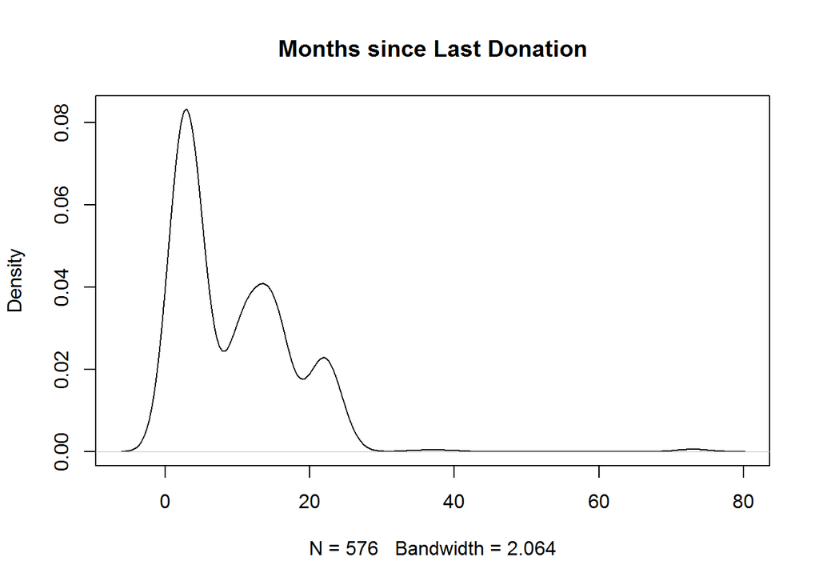

```r
#Density plot
plot(density(datamodel$Months.since.Last.Donation),main="Months since Last Donation")
```

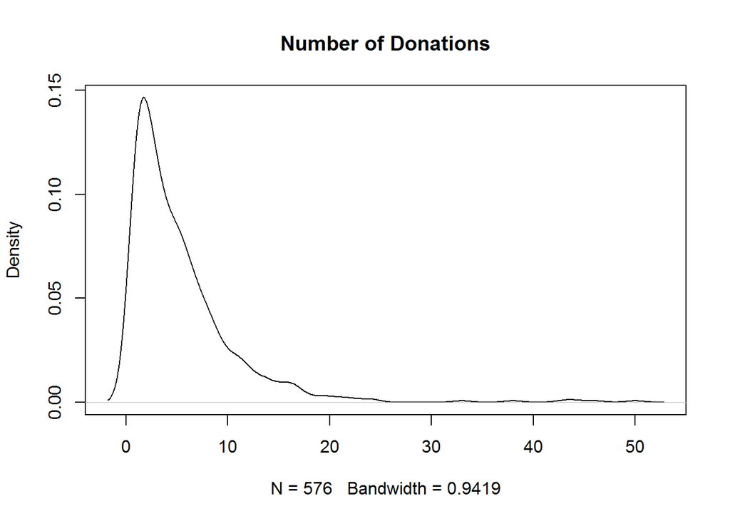

```r
plot(density(datamodel$Number.of.Donations),main="Number of Donations")
```

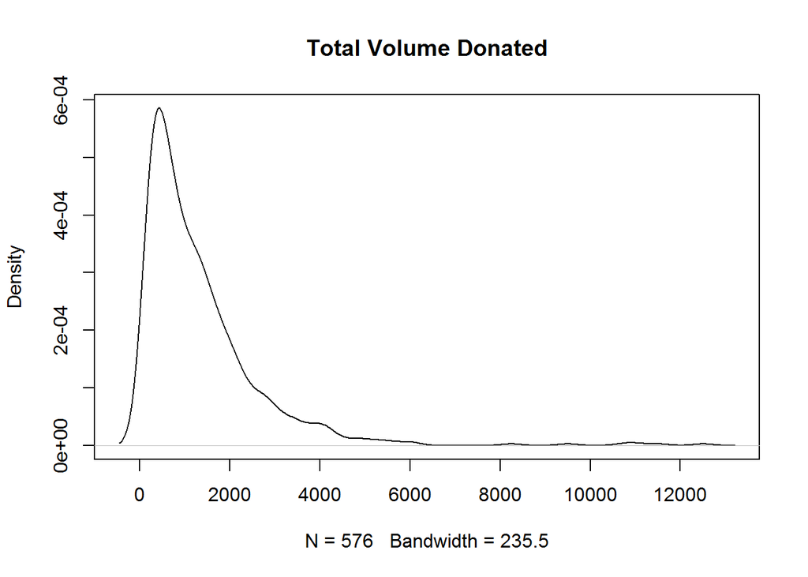

```r
plot(density(datamodel$Total.Volume.Donated..c.c..),main="Total Volume Donated")
```

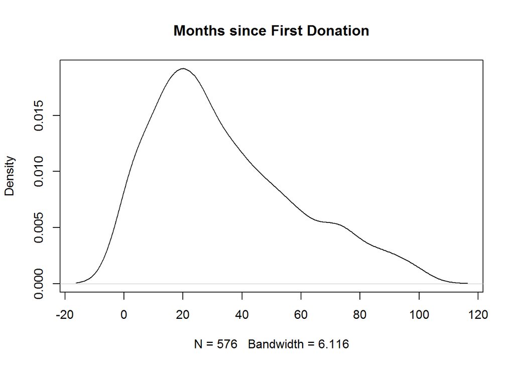

```r
plot(density(datamodel$Months.since.First.Donation),main="Months since First Donation")
```

```r
par(mfrow=c(2,2))
#for(i in 2:5) {
#  hist(datamodel[,i], main=names(datamodel)[i])
#}
```

### Densityplot

For the second and third graph, the shape of the density curve is similar which makes sense because the volume of every donation should be based on a standard unit, hence the more times a person donated blood, the more volume he would have donated. we can also observe that there are more number of people who donated a smaller number of volume and times.

The fourth graph shows the distribution of months since first donation. From this we can observe that most people’s first donation is around 20 months ago until March 2007.

### 1c) Feature Engineering

There is a multicollinearity issue in the model because Number.Of.Donations and Total.Volume.Donated..c.c.. are perfectly correlated (the correlation is 1). So we consider only one of the two variables - Number.Of.Donations

```r
cor(datamodel[,4],datamodel[,3])
```

```
## [1] 1
```

```r
datamodel = datamodel[, -4]
```

### 1d) Splitting of Data into training and validation set

We split the data into training and validation set to enable testing of the various models

```r
a=229629
N=nrow(datamodel)
set.seed(a)
Perct=0.7
train.index <- sample(1:N, round(N*Perct))
valid.index <- - train.index

datatrain=datamodel[train.index,]
datavalid=datamodel[valid.index,]

xtrain=model.matrix(Made.Donation.in.March.2007 ~ ., datatrain)[,-c(1,2)]
ytrain=datatrain[, "Made.Donation.in.March.2007"]
xvalid=model.matrix(Made.Donation.in.March.2007 ~ ., datavalid)[,-c(1,2)]
yvalid=datavalid[, "Made.Donation.in.March.2007"]
```

## 2) Building Models

We build a series of models and predict the probabilities of a person returning to donate blood on March 2007

### 2a) Logistic regression model

```r
glm <- glm(Made.Donation.in.March.2007 ~ ., data=datatrain, family=binomial())
summary(glm)
```

```
##
## Call:
## glm(formula = Made.Donation.in.March.2007 ~ ., family = binomial(),
##     data = datatrain)
##
## Deviance Residuals:
##     Min       1Q   Median       3Q      Max
## -2.3767  -0.8111  -0.5233  -0.2432   2.6048
##
## Coefficients:
##                               Estimate Std. Error z value Pr(>|z|)
## (Intercept)                 -0.5555155  0.3160777  -1.758 0.078828 .
## X                            0.0001671  0.0005857   0.285 0.775411
## Months.since.Last.Donation  -0.0927691  0.0229415  -4.044 5.26e-05 ***
## Number.of.Donations          0.1280761  0.0331831   3.860 0.000114 ***
## Months.since.First.Donation -0.0220005  0.0079957  -2.752 0.005932 **
## ---
## Signif. codes:  0 '***' 0.001 '**' 0.01 '*' 0.05 '.' 0.1 ' ' 1
##
## (Dispersion parameter for binomial family taken to be 1)
##
##     Null deviance: 444.81  on 402  degrees of freedom
## Residual deviance: 392.39  on 398  degrees of freedom
## AIC: 402.39
##
## Number of Fisher Scoring iterations: 5
```

```r
## model selectin by AIC
library("MASS")
glm.best <- stepAIC(glm, direction="both")
```

```
## Start:  AIC=402.39
## Made.Donation.in.March.2007 ~ X + Months.since.Last.Donation +
##     Number.of.Donations + Months.since.First.Donation
##
##                               Df Deviance    AIC
## - X                            1   392.47 400.47
## <none>                             392.39 402.39
## - Months.since.First.Donation  1   400.87 408.87
## - Number.of.Donations          1   410.12 418.12
## - Months.since.Last.Donation   1   411.24 419.24
##
## Step:  AIC=400.47
## Made.Donation.in.March.2007 ~ Months.since.Last.Donation + Number.of.Donations +
##     Months.since.First.Donation
##
##                               Df Deviance    AIC
## <none>                             392.47 400.47
## + X                            1   392.39 402.39
## - Months.since.First.Donation  1   400.91 406.91
## - Number.of.Donations          1   410.29 416.29
## - Months.since.Last.Donation   1   411.41 417.41
```

```r
summary(glm.best)
```

```
##
## Call:
## glm(formula = Made.Donation.in.March.2007 ~ Months.since.Last.Donation +
##     Number.of.Donations + Months.since.First.Donation, family = binomial(),
##     data = datatrain)
##
## Deviance Residuals:
##     Min       1Q   Median       3Q      Max
## -2.3995  -0.8075  -0.5246  -0.2428   2.5980
##
## Coefficients:
##                              Estimate Std. Error z value Pr(>|z|)
## (Intercept)                 -0.493900   0.230182  -2.146 0.031898 *
## Months.since.Last.Donation  -0.092839   0.022915  -4.051 5.09e-05 ***
## Number.of.Donations          0.128391   0.033181   3.869 0.000109 ***
## Months.since.First.Donation -0.021925   0.007983  -2.746 0.006026 **
## ---
## Signif. codes:  0 '***' 0.001 '**' 0.01 '*' 0.05 '.' 0.1 ' ' 1
##
## (Dispersion parameter for binomial family taken to be 1)
##
##     Null deviance: 444.81  on 402  degrees of freedom
## Residual deviance: 392.47  on 399  degrees of freedom
## AIC: 400.47
##
## Number of Fisher Scoring iterations: 5
```

```r
## categorical prediction (use fixed cutoff = 0.5)
glm.prob <- predict(glm.best, newdata=datavalid, type="response")
glm.pred <- ifelse(glm.prob > 0.5,"P1","P0")

# confusion matrix
confusion.mat <- table(glm.pred, datavalid$Made.Donation.in.March.2007)
confusion.mat
```

```
##
## glm.pred   0   1
##       P0 130  37
##       P1   2   4
```

```r
misclassfication_rate_glm <- 1 - (confusion.mat[2, 2] + confusion.mat[1, 1]) / nrow(datavalid)
```

### 2b) Ridge Regression models

```r
##Set the same seed for all models
library(glmnet)
set.seed(a)
ridgecv=cv.glmnet(xtrain,ytrain,family = "binomial", alpha = 0,type.measure = "class")
ridgelam=ridgecv$lambda.min
##optimal lambda for ridge
ridgelam
```

```
## [1] 0.04298034
```

```r
coeffridge=predict(ridgecv, type="coefficient", s=ridgelam)
coeffridge
```

```
## 4 x 1 sparse Matrix of class "dgCMatrix"
##                                       1
## (Intercept)                 -0.65085925
## Months.since.Last.Donation  -0.07260112
## Number.of.Donations          0.07775085
## Months.since.First.Donation -0.01146101
```

```r
## categorical prediction (use fixed cutoff = 0.5)
ridge.prob <- predict(ridgecv, s=ridgelam, newx=xvalid,exact=TRUE,type="response")
ridge.pred <- ifelse(ridge.prob > 0.5,"P1","P0")

# confusion matrix
confusion.mat <- table(ridge.pred, datavalid$Made.Donation.in.March.2007)
confusion.mat
```

```
##
## ridge.pred   0   1
##         P0 132  39
##         P1   0   2
```

```r
misclassfication_rate_ridge <- 1 - (confusion.mat[2, 2] + confusion.mat[1, 1]) / nrow(datavalid)
```

### 2c) Lasso Model

```r
set.seed(a)
lassocv=cv.glmnet(xtrain,ytrain,family = "binomial", alpha = 1,type.measure = "class")
lassolam=lassocv$lambda.min
##optimal lambda for ridge
lassolam
```

```
## [1] 0.01375056
```

```r
coefflasso=predict(lassocv, type="coefficient", s=lassolam)
coefflasso
```

```
## 4 x 1 sparse Matrix of class "dgCMatrix"
##                                       1
## (Intercept)                 -0.61365539
## Months.since.Last.Donation  -0.08331610
## Number.of.Donations          0.08088077
## Months.since.First.Donation -0.01093326
```

```r
## categorical prediction (use fixed cutoff = 0.5)
lasso.prob <- predict(lassocv, s=lassolam, newx=xvalid,exact=TRUE,type="response")
lasso.pred <- ifelse(lasso.prob > 0.5,"P1","P0")

# confusion matrix
confusion.mat <- table(lasso.pred, datavalid$Made.Donation.in.March.2007)
confusion.mat
```

```
##
## lasso.pred   0   1
##         P0 132  39
##         P1   0   2
```

```r
misclassfication_rate_lasso <- 1 - (confusion.mat[2, 2] + confusion.mat[1, 1]) / nrow(datavalid)
```

### 2d) Elastic Model

```r
set.seed(a)
K=10
n=nrow(xtrain)
fold=sample(rep(seq(K),length=n))

alphas <- seq(0, 1, 0.01)
elscv.error = data.frame(alpha=alphas)
for (i in 1:length(alphas)){
  elscv = cv.glmnet(xtrain, ytrain, family="binomial", alpha=alphas[i], foldid=fold,type.measure = "class")
  elscv.error[i, "lambda.min"] = elscv$lambda.min
  elscv.error[i, "error.min"] = min(elscv$cvm)
}

##optimal alpha & lambda for elastic mod
elslam=elscv.error[which.min(elscv.error$error.min), "lambda.min"]
elsalpha=elscv.error[which.min(elscv.error$error.min), "alpha"]
elslam
```

```
## [1] 0.04298034
```

```r
elsalpha
```

```
## [1] 0
```

```r
set.seed(a)
##prediction of test data using mod with optimal alpha & lambda
elscv=cv.glmnet(xtrain, ytrain,family = "binomial", alpha = elsalpha,type.measure = "class")
coeffels=predict(elscv, type="coefficient", s=elslam)
coeffels
```

```
## 4 x 1 sparse Matrix of class "dgCMatrix"
##                                       1
## (Intercept)                 -0.65085925
## Months.since.Last.Donation  -0.07260112
## Number.of.Donations          0.07775085
## Months.since.First.Donation -0.01146101
```

```r
## categorical prediction (use fixed cutoff = 0.5)
en.prob <- predict(elscv,s=elslam,newx=xvalid,type="response",exact=TRUE)
#hist(Default$glm4.prob)
en.pred <- ifelse(en.prob > 0.5,"P1","P0")

# confusion matrix
confusion.mat <- table(en.pred, datavalid$Made.Donation.in.March.2007)
confusion.mat
```

```
##
## en.pred   0   1
##      P0 132  39
##      P1   0   2
```

```r
misclassfication_rate_en <- 1 - (confusion.mat[2, 2] + confusion.mat[1, 1]) / nrow(datavalid)
```

## 2e) Tree

```r
library("tree")

##Growing a tree
tree1=tree(Made.Donation.in.March.2007~.,data=datatrain[,-1])
summary(tree1)
```

```
##
## Classification tree:
## tree(formula = Made.Donation.in.March.2007 ~ ., data = datatrain[,
##     -1])
## Number of terminal nodes:  6
## Residual mean deviance:  0.9177 = 364.3 / 397
## Misclassification error rate: 0.206 = 83 / 403
```

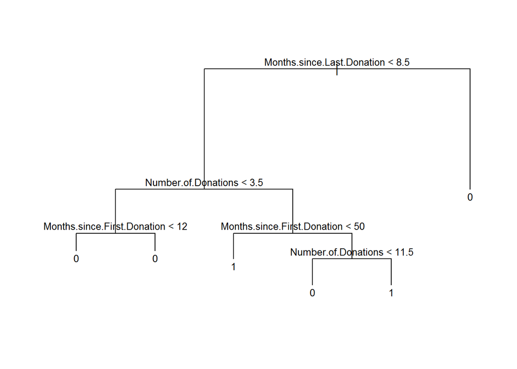

```r
##Pruning by CV
set.seed(a)
tree1.cv=cv.tree(tree1,method="misclass")

##optimal size
optimal1=which.min(tree1.cv$dev)
optimal.size1=tree1.cv$size[optimal1]

##final pruned tree
tree1.pruned=prune.tree(tree1,best=optimal.size1)
plot(tree1.pruned)
text(tree1.pruned,cex=0.8)
```

```r
## categorical prediction (use fixed cutoff = 0.5)
tree.prob <- predict(tree1.pruned,newdata=datavalid,type="vector")
#hist(Default$glm4.prob)
tree.pred <- ifelse(tree.prob[,2] > 0.5,"P1","P0")

# confusion matrix
confusion.mat <- table(tree.pred, datavalid$Made.Donation.in.March.2007)
confusion.mat
```

```
##
## tree.pred   0   1
##        P0 108  17
##        P1  24  24
```

```r
misclassfication_rate_tree <- 1 - (confusion.mat[2, 2] + confusion.mat[1, 1]) / nrow(datavalid)
```

## 2f) Random Forest

```r
library("randomForest")

##find optimal mtry
p=(ncol(datatrain)-2)
mserf=rep(0,p)
for (i in 1:p){
  set.seed(a)
  rf=randomForest(Made.Donation.in.March.2007~.,data=datatrain[,-1],ntree=1001,mtry=i)
  mserf[i]=rf$err.rate[1001]
}
optimal2=which.min(mserf)

##random forest  with optimal mtry
set.seed(a)
tree2=randomForest(Made.Donation.in.March.2007~.,data=datatrain[,-1],ntree=1001,mtry=optimal2)

importance(tree2)
```

```
##                             MeanDecreaseGini
## Months.since.Last.Donation          28.90464
## Number.of.Donations                 27.01592
## Months.since.First.Donation         33.84954
```

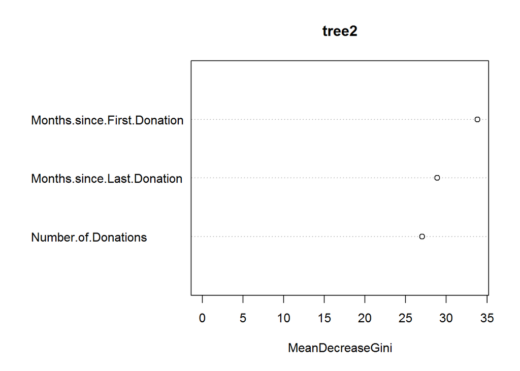

```r
varImpPlot(tree2)
```

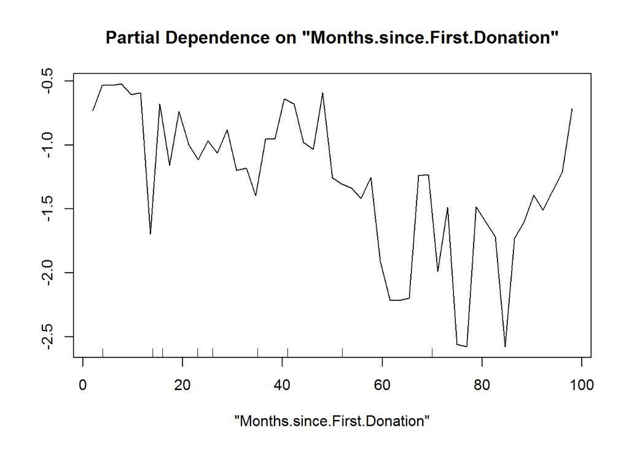

```r
partialPlot(tree2, datatrain,x.var="Months.since.First.Donation",which.class="1")
```

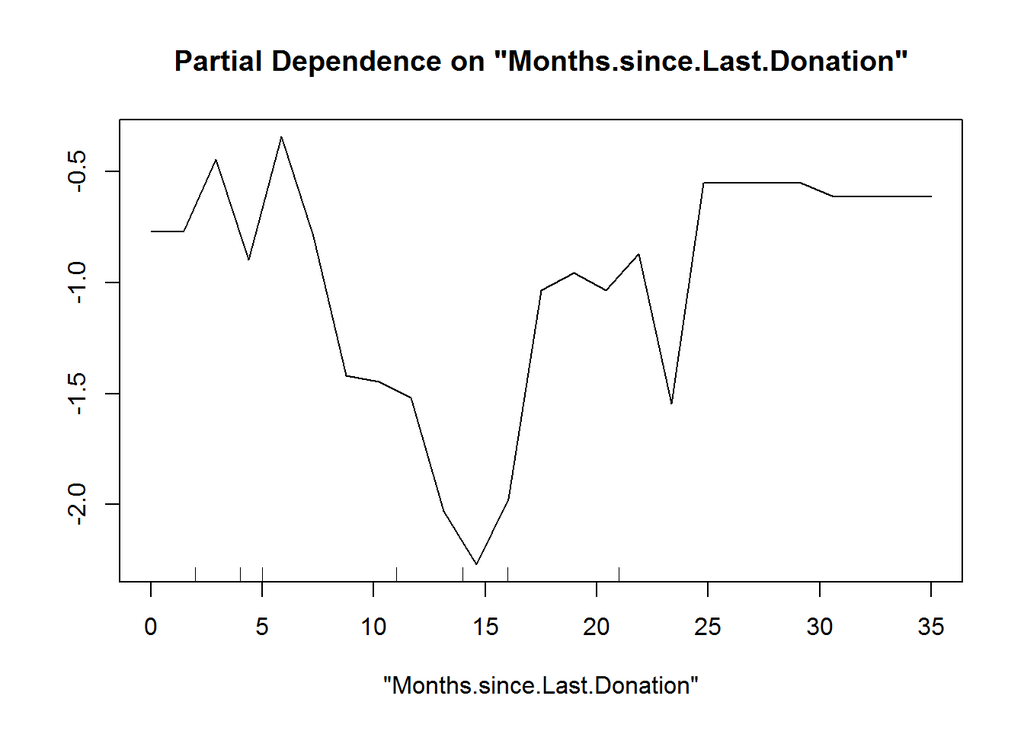

```r
partialPlot(tree2, datatrain,x.var="Months.since.Last.Donation",which.class="1")
```

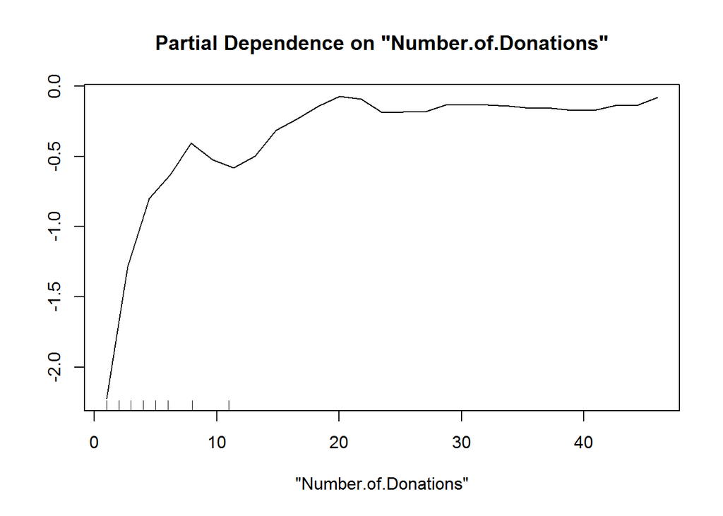

```r
partialPlot(tree2, datatrain,x.var="Number.of.Donations",which.class="1")
```

```r
## categorical prediction (use fixed cutoff = 0.5)
rf.prob <- predict(tree2,newdata=datavalid,type="prob")
rf.pred <- ifelse(rf.prob[,2] > 0.5,"P1","P0")

# confusion matrix
confusion.mat <- table(rf.pred, datavalid$Made.Donation.in.March.2007)
confusion.mat
```

```
##
## rf.pred   0   1
##      P0 118  24
##      P1  14  17
```

```r
misclassfication_rate_rf <- 1 - (confusion.mat[2, 2] + confusion.mat[1, 1]) / nrow(datavalid)
```

### 2g) Gradient Boosting Machine

````r
library("xgboost")
library("ggplot2")
ytrainnum=as.numeric(ytrain)-1
dtrain <- xgb.DMatrix(data=xtrain, label=ytrainnum)

objective <- "binary:logistic"
cv.fold <- 10
#```

# parameter ranges
max_depths <- c(1, 2, 3)  # candidates for d
etas <- c(0.01,0.0075, 0.005, 0.001)  # candidates for lambda
subsamples <- c(0.3,0.4,0.5,0.6, 0.75, 1)
colsamples <- c(0.6, 0.8,0.9,0.95,1)

tune.out <- data.frame()
for (max_depth in max_depths) {
  for (eta in etas) {
    for (subsample in subsamples) {
      for (colsample in colsamples) {
        # **calculate max n.trees**
        n.max <- round(100 / (eta * sqrt(max_depth)))
        set.seed(a)
        xgb.cv.fit <- xgb.cv(data = dtrain, objective=objective, nfold=cv.fold, early_stopping_rounds=100, verbose=0,
                             nrounds=n.max, max_depth=max_depth, eta=eta, subsample=subsample, colsample_bytree=colsample)
        n.best <- xgb.cv.fit$best_ntreelimit
        if (objective == "reg:linear") {
          cv.err <- xgb.cv.fit$evaluation_log$test_rmse_mean[n.best]
        } else if (objective == "binary:logistic") {
          cv.err <- xgb.cv.fit$evaluation_log$test_error_mean[n.best]
        }
        out <- data.frame(max_depth=max_depth, eta=eta, subsample=subsample, colsample=colsample, n.max=n.max, nrounds=n.best, cv.err=cv.err)
        tune.out <- rbind(tune.out, out)
      }
    }
  }
}
opt <- which.min(tune.out$cv.err)
max_depth.opt <- tune.out$max_depth[opt]
eta.opt <- tune.out$eta[opt]
subsample.opt <- tune.out$subsample[opt]
colsample.opt <- tune.out$colsample[opt]
nrounds.opt <- tune.out$nrounds[opt]
opt;max_depth.opt;eta.opt;subsample.opt;colsample.opt;nrounds.opt
````

```
## [1] 305
```

```
## [1] 3
```

```
## [1] 0.005
```

```
## [1] 0.3
```

```
## [1] 1
```

```
## [1] 204
```

```r
# final model
set.seed(a)
xgbmod=xgboost(data=dtrain, objective="binary:logistic", nround=nrounds.opt, max.depth=max_depth.opt, eta=eta.opt, subsample=subsample.opt, colsample_bytree=colsample.opt,verbose = 0)

# variable importance
importance_matrix <- xgb.importance(model = xgbmod, feature_names = colnames(xtrain))
importance_matrix
```

```
##                        Feature      Gain     Cover Frequency
## 1:  Months.since.Last.Donation 0.3818113 0.3776852 0.2771574
## 2:         Number.of.Donations 0.3450441 0.3478363 0.3390863
## 3: Months.since.First.Donation 0.2731445 0.2744785 0.3837563
```

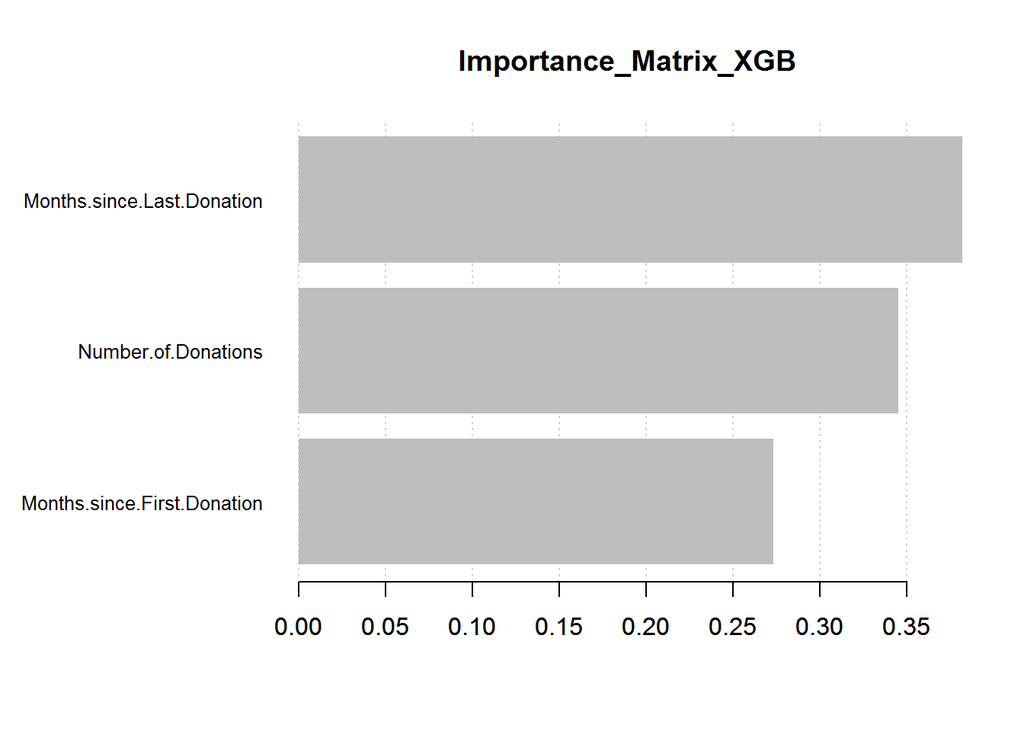

```r
xgb.plot.importance(importance_matrix=importance_matrix,cex=0.8,main="Importance_Matrix_XGB")
```

## Interpretation：

“Months.since.Last.Donation”" is the most important variable, followed by “number of donations” in predicting whether a donor will return on March 2007

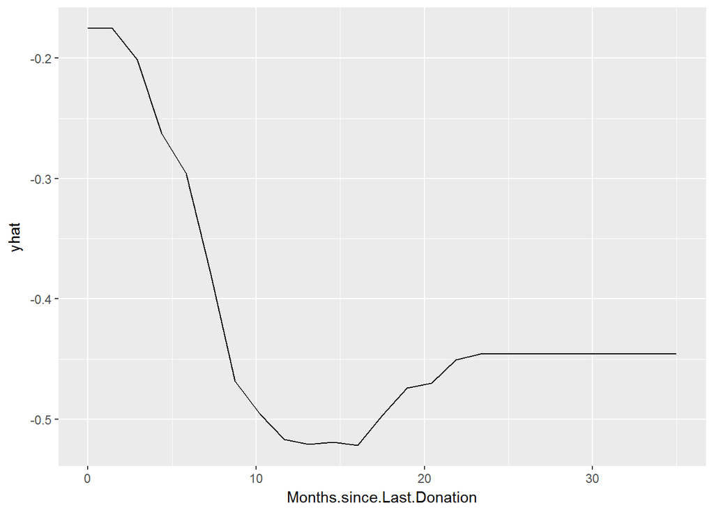

```r
### Partial Dependence by pdp
library("pdp")
pd1 <- partial(xgbmod, train=xtrain, pred.var = "Months.since.Last.Donation", chull = TRUE)
autoplot(pd1)
```

### Interpretation：

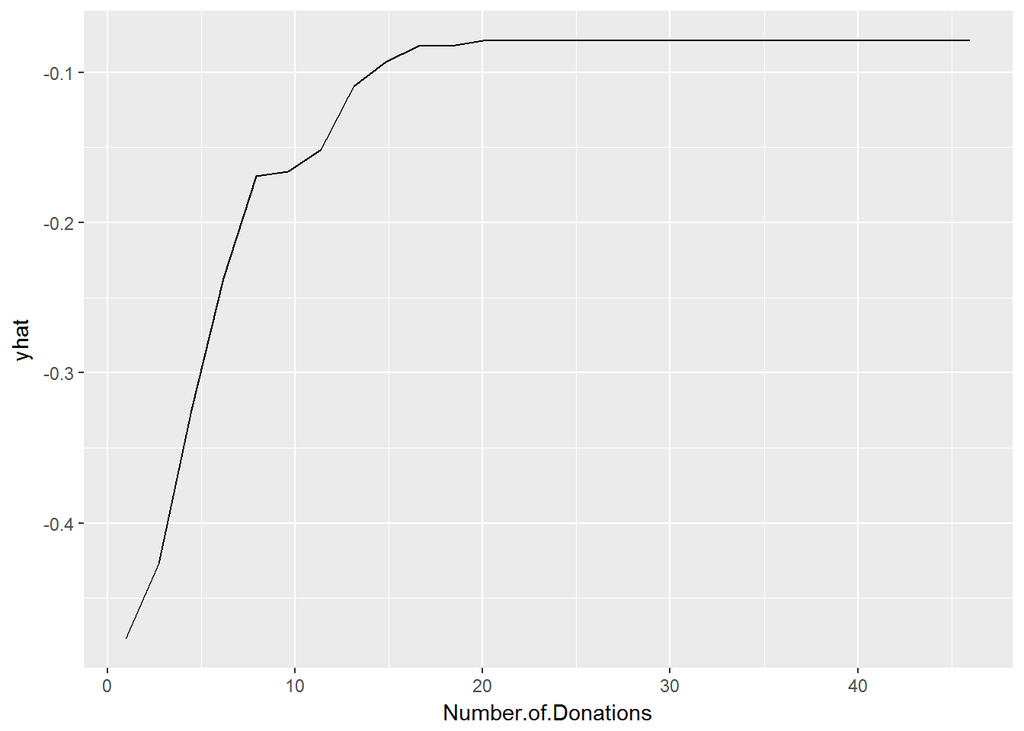

```r
pd2 <- partial(xgbmod, train=xtrain, pred.var = "Number.of.Donations", chull = TRUE)
autoplot(pd2)
```

### Interpretation：

The larger the number of donations, the more likely would the donor return to donate in MArch 2007.

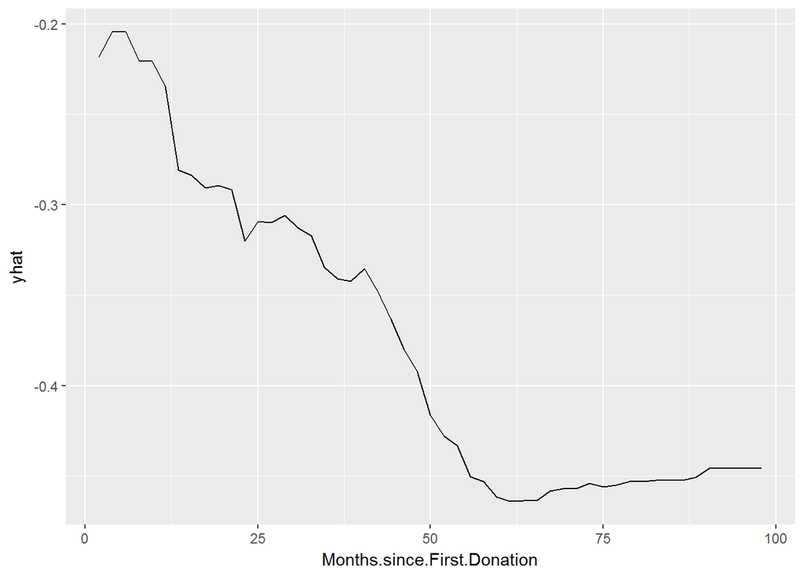

```r
pd3 <- partial(xgbmod, train=xtrain, pred.var = "Months.since.First.Donation", chull = TRUE)
autoplot(pd3)
```

### Interpretation：

Assuming all else constant, the larger the number of months since the donor’s first donation, the lesser prbability of the donor returning to donate in MArch 2007.

```r
## categorical prediction (use fixed cutoff = 0.5)
xgb.prob <- predict(xgbmod, xvalid,type="prob")
xgb.pred <-ifelse(xgb.prob > 0.5,"P1","P0")

# confusion matrix
confusion.mat <- table(xgb.pred, datavalid$Made.Donation.in.March.2007)
confusion.mat
```

```
##
## xgb.pred   0   1
##       P0 125  27
##       P1   7  14
```

```r
misclassfication_rate_xgb <- 1 - (confusion.mat[2, 2] + confusion.mat[1, 1]) / nrow(datavalid)
```

### 2h) Ensemble model - Averaging

There are many ways to ensemble the above models. Here we choose the simplest method which is simple averaging of the probabilities of the above derived models from 2a) to 2g).

```r
predEnsemble_average = (glm.prob + ridge.prob + lasso.prob + en.prob + tree.prob[,2] + rf.prob[,2] + xgb.prob)/7
predEnsemble_average_yesno <- ifelse(predEnsemble_average > 0.5, 1, 0)
misclassification_rate_ensemble_average <- sum(predEnsemble_average_yesno != datavalid$Made.Donation.in.March.2007)/nrow(datavalid)
```

### 2i) Ensemble model - Majority

The other esemble model is to predict based on the majority votes by the models from 2a) to 2g). If 4 or more models predict the response varible as “1”, then this model would also predict the response variable as “1”, else, it will predict the response variable as “0”.

```r
predglm2a_yesno <- ifelse(glm.prob > 0.5, 1, 0)
predrid2b_yesno <- ifelse(ridge.prob > 0.5, 1, 0)
predlas2c_yesno <- ifelse(lasso.prob > 0.5, 1, 0)
predels2d_yesno <- ifelse(en.prob > 0.5, 1, 0)
predtre2e_yesno <- ifelse(tree.prob[,2] > 0.5, 1, 0)
predrft2f_yesno <- ifelse(rf.prob[,2] > 0.5, 1, 0)
predxgb2g_yesno <- ifelse(xgb.prob > 0.5, 1, 0)
pred.ensemble.2 <- data.frame(predglm2a_yesno , predrid2b_yesno,predlas2c_yesno,predels2d_yesno,predtre2e_yesno,predrft2f_yesno, predxgb2g_yesno)
library("functional")
finalPred <- apply(pred.ensemble.2, 1, Compose(table,
                                         function(i) i==max(i),
                                         which,
                                         names,
                                         function(i) paste0(i, collapse='/')
)
)
misclassification_rate_ensemble_majority <- sum(finalPred != datavalid$Made.Donation.in.March.2007)/nrow(datavalid)
```

## 3) Model Comparison

After comparison made below, we have chose XGBoosting as the best model because it has the lowest misclassification rate

```r
misclassfication_rate_glm
```

```
## [1] 0.2254335
```

```r
misclassfication_rate_ridge
```

```
## [1] 0.2254335
```

```r
misclassfication_rate_lasso
```

```
## [1] 0.2254335
```

```r
misclassfication_rate_en
```

```
## [1] 0.2254335
```

```r
misclassfication_rate_tree
```

```
## [1] 0.2369942
```

```r
misclassfication_rate_rf
```

```
## [1] 0.2196532
```

```r
misclassfication_rate_xgb
```

```
## [1] 0.1965318
```

```r
misclassification_rate_ensemble_majority
```

```
## [1] 0.2312139
```

```r
misclassification_rate_ensemble_average
```

```
## [1] 0.2196532
```

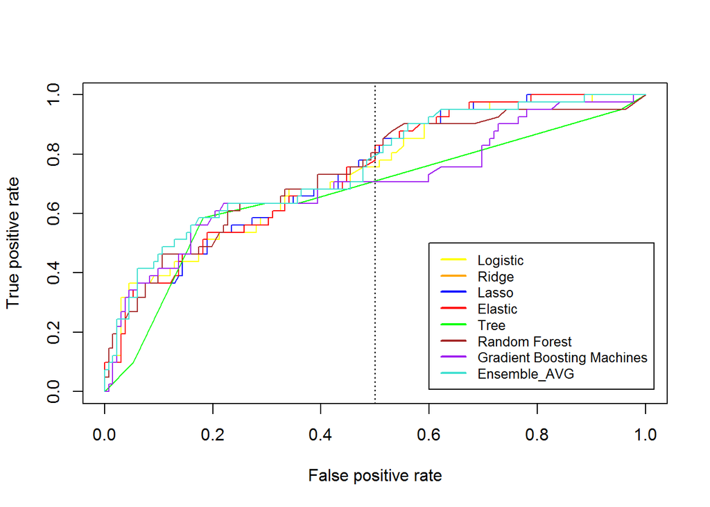

```r
library("ROCR")
mod_glm_pred=prediction(glm.prob, yvalid)
mod_ridge_pred=prediction(ridge.prob, yvalid)
mod_lasso_pred=prediction(lasso.prob, yvalid)
mod_en_pred=prediction(en.prob, yvalid)
mod_tree_pred=prediction(tree.prob[,2], yvalid)
mod_rf_pred=prediction(rf.prob[,2], yvalid)
mod_xgb_pred=prediction(xgb.prob, yvalid)
modEnsemblePred_avg=prediction(predEnsemble_average, yvalid)

# ROC Curve

mod_glm.ROC <- performance(mod_glm_pred, measure="tpr", x.measure="fpr")
mod_ridge.ROC <- performance(mod_ridge_pred, measure="tpr", x.measure="fpr")
mod_lasso.ROC <- performance(mod_lasso_pred, measure="tpr", x.measure="fpr")
mod_en.ROC <- performance(mod_en_pred, measure="tpr", x.measure="fpr")
mod_tree.ROC <- performance(mod_tree_pred, measure="tpr", x.measure="fpr")
mod_rf.ROC <- performance(mod_rf_pred, measure="tpr", x.measure="fpr")
mod_xgb.ROC <- performance(mod_xgb_pred, measure="tpr", x.measure="fpr")
mod_ensemble_avg.ROC <- performance(modEnsemblePred_avg, measure="tpr", x.measure="fpr")

plot(mod_glm.ROC, col="yellow")
plot(mod_ridge.ROC, col="orange",add=TRUE)
plot(mod_lasso.ROC, col="blue",add=TRUE)
plot(mod_en.ROC, col="red",add=TRUE)
plot(mod_tree.ROC, col="green",add=TRUE)
plot(mod_rf.ROC, col="brown",add=TRUE)
plot(mod_xgb.ROC, col="purple",add=TRUE)
plot(mod_ensemble_avg.ROC, col="turquoise",add=TRUE)
abline(v=0.5,col="black",lty=3)

legend(x=0.6, y=0.5, legend=c("Logistic","Ridge","Lasso","Elastic","Tree", "Random Forest", "Gradient Boosting Machines","Ensemble_AVG"), lty=c(1, 1, 1), lwd=c(2, 2, 2), col=c("yellow","orange", "blue", "red","green","brown","purple","turquoise"),cex=0.8)
```

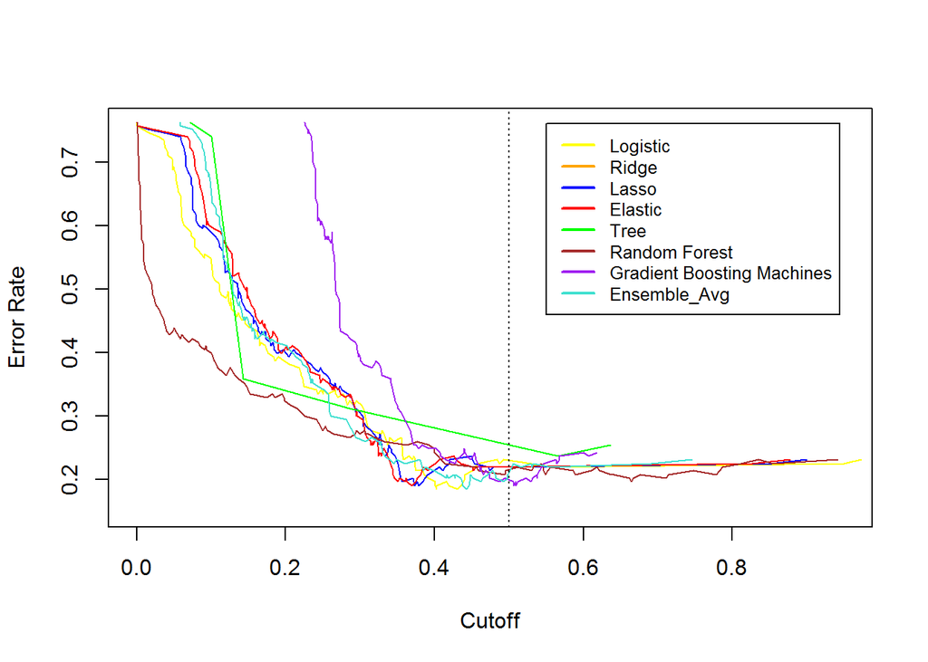

```r
# Plot of Misclassification rate against cutoff
mod_glm.err=performance(mod_glm_pred, measure="err")
mod_ridge.err=performance(mod_ridge_pred, measure="err")
mod_lasso.err=performance(mod_lasso_pred, measure="err")
mod_en.err=performance(mod_en_pred, measure="err")
mod_tree.err=performance(mod_tree_pred, measure="err")
mod_rf.err=performance(mod_rf_pred, measure="err")
mod_xgb.err=performance(mod_xgb_pred, measure="err")
mod_ensemble_avg.err=performance(modEnsemblePred_avg, measure="err")

plot(mod_glm.err, col="yellow",ylim=c(0.15,0.76),xlim=c(-0.0,0.95))
plot(mod_ridge.err, col="orange",ylim=c(0.15,0.8),xlim=c(-0.0,0.95),add=TRUE)
plot(mod_lasso.err, col="blue",add=TRUE)
plot(mod_en.err, col="red",add=TRUE)
plot(mod_tree.err, col="green",add=TRUE)
plot(mod_rf.err, col="brown",add=TRUE)
plot(mod_xgb.err, col="purple",add=TRUE)
plot(mod_ensemble_avg.err, col="turquoise",add=TRUE)
abline(v=0.5,col="black",lty=3)

legend(x=0.55, y=0.76, legend=c("Logistic","Ridge","Lasso","Elastic","Tree", "Random Forest", "Gradient Boosting Machines","Ensemble_Avg"), lty=c(1, 1, 1), lwd=c(2, 2, 2), col=c("yellow","orange", "blue", "red","green","brown","purple","turquoise"),cex=0.8)
```

```r
# AUC values
mod_glm.auc <- performance(mod_glm_pred, "auc")
mod_ridge.auc <- performance(mod_ridge_pred, "auc")
mod_lasso.auc <- performance(mod_lasso_pred, "auc")
mod_en.auc <- performance(mod_en_pred, "auc")
mod_tree.auc <- performance(mod_tree_pred, "auc")
mod_rf.auc <- performance(mod_rf_pred, "auc")
mod_xgb.auc <- performance(mod_xgb_pred, "auc")
mod_ensemble_avg.auc <- performance(modEnsemblePred_avg, "auc")

mod_glm.auc@y.values[[1]]
```

```
## [1] 0.7355876
```

```r
mod_ridge.auc@y.values[[1]]
```

```
## [1] 0.7411308
```

```r
mod_lasso.auc@y.values[[1]]
```

```
## [1] 0.7424242
```

```r
mod_en.auc@y.values[[1]]
```

```
## [1] 0.7411308
```

```r
mod_tree.auc@y.values[[1]]
```

```
## [1] 0.6730414
```

```r
mod_rf.auc@y.values[[1]]
```

```
## [1] 0.7389135
```

```r
mod_xgb.auc@y.values[[1]]
```

```
## [1] 0.7038987
```

```r
mod_ensemble_avg.auc@y.values[[1]]
```

```
## [1] 0.7562823
```

## 4) Final Model

Best Model : We find best cutoff based on cost. False negative has lower cost than False positive

Reason is because we want to make sure that people are who are predicted to be return donors actually come

If we get false negative, it means people who are not predicted to come actually come - which is not such a bad thing :)

We set the cutoff at the best cutoff above.

In terms of misclassification rate, the xgboost models performs best among all the models(lowest misclass rate)

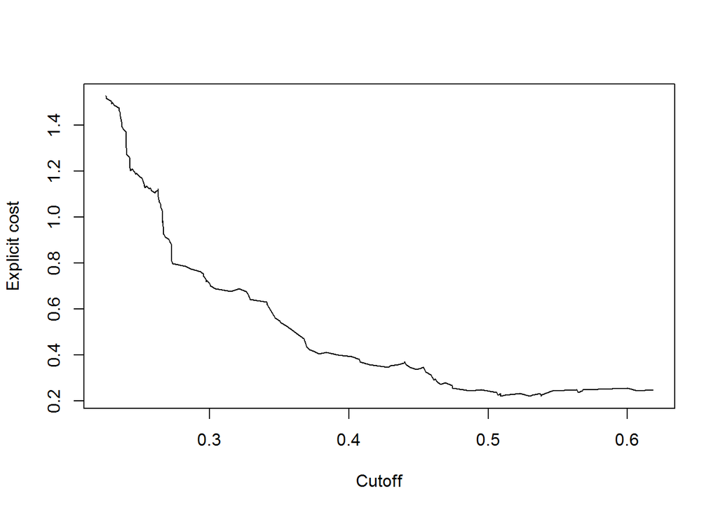

```r
cost.xgb <- performance(mod_xgb_pred, measure = "cost", cost.fn = 1, cost.fp = 2)
plot(cost.xgb)
```

```r
minimum_cost <- which.min(cost.xgb@y.values[[1]])
minimum_cost
```

```
## [1] 12
```

```r
# Best cutoff that gives the minimum cost
best_cutoff <- cost.xgb@x.values[[1]][minimum_cost]
best_cutoff
```

```
## [1] 0.5381426
```

```r
xgb.prob <- predict(xgbmod, xvalid,type="prob")
xgb.pred <-ifelse(xgb.prob > best_cutoff,1,0)

# confusion matrix based on the optimal cutoff
confusion.mat <- table(xgb.pred, datavalid$Made.Donation.in.March.2007)
confusion.mat
```

```
##
## xgb.pred   0   1
##        0 129  33
##        1   3   8
```

```r
TP <- confusion.mat[2, 2]
TP
```

```
## [1] 8
```

```r
TN <- confusion.mat[1, 1]
TN
```

```
## [1] 129
```

```r
FP <- confusion.mat[2, 1]
FP
```

```
## [1] 3
```

```r
FN <- confusion.mat[1, 2]
FN
```

```
## [1] 33
```

```r
sensitivity <- TP / (TP + FN)
sensitivity
```

```
## [1] 0.195122
```

```r
fallout <- FP/ (FP + TN)
fallout
```

```
## [1] 0.02272727
```

```r
specificity <- TN / (FP + TN)
specificity
```

```
## [1] 0.9772727
```

```r
precision <- TP / (TP + FP)
precision
```

```
## [1] 0.7272727
```

```r
missout <- FN/ (TP + FN)
missout
```

```
## [1] 0.804878
```

```r
accuracy <- (TP + TN) / nrow(datavalid)
accuracy
```

```
## [1] 0.7919075
```

## 5.1) Create submission file(xgboost)

```r
testdata = read.csv("D:/2_Materials/1_Personal/21_MSBA/5_Semester 1/3_STATISTICS/Final project/3_Predict Blood Donations/Datasets/Testing data/Testing.csv", stringsAsFactors = FALSE)

#type conversion
testdata$X = as.numeric(testdata$X)
testdata$Months.since.Last.Donation = as.numeric(testdata$Months.since.Last.Donation)
testdata$Number.of.Donations = as.numeric(testdata$Number.of.Donations)
testdata$Total.Volume.Donated..c.c.. = as.numeric(testdata$Total.Volume.Donated..c.c..)
testdata$Months.since.First.Donation = as.numeric(testdata$Months.since.First.Donation)

dtest <- xgb.DMatrix(data = data.matrix( testdata ), missing = NA )

xgb.prob.test <- predict(xgbmod, dtest,type="prob")

test.submit = data.frame(X=1:nrow(testdata))
test.submit$X = testdata[,"X"]
test.submit$Donated_prob = xgb.prob.test
colnames(test.submit) = c("", "Made Donation in March 2007")

# save prediction to file
write.csv(test.submit, file="D:/2_Materials/1_Personal/21_MSBA/5_Semester 1/3_STATISTICS/Final project/3_Predict Blood Donations/Datasets/Testing data/Testing_Prob.csv", row.names = FALSE)
```

## 5.2) Create submission file(ensemble)

```r
#glm
## categorical prediction
glm.prob.test <- predict(glm.best, newdata=testdata, type="response")

temp =  testdata[,2:3]
temp$Months.since.First.Donation = testdata$Months.since.First.Donation
test.matrix = as.matrix(temp)
ridge.prob.test <- predict(ridgecv, s=ridgelam, newx=test.matrix,exact=TRUE,type="response")

#Lasso
lasso.prob.test <- predict(lassocv, s=lassolam, newx=test.matrix,exact=TRUE,type="response")

#Elastic
en.prob.test <- predict(elscv,s=elslam,newx=test.matrix,type="response",exact=TRUE)

#Tree
tree.prob.test <- predict(tree1.pruned,newdata=testdata,type="vector")

#Random Forest
rf.prob.test <- predict(tree2,newdata=testdata,type="prob")

#Gradient Boosting Machine
xgb.prob.test
```

[output not shown]

```r
#ensemble
total.average.prob.test = (xgb.prob.test + rf.prob.test[,2] + tree.prob.test[,2] + en.prob.test + lasso.prob.test + ridge.prob.test + glm.prob.test)/7

test.submit = data.frame(X=1:nrow(testdata))
test.submit$X = testdata[,"X"]
test.submit$Donated_prob = total.average.prob.test
colnames(test.submit) = c("", "Made Donation in March 2007")

# save prediction to file
write.csv(test.submit, file="D:/2_Materials/1_Personal/21_MSBA/5_Semester 1/3_STATISTICS/Final project/3_Predict Blood Donations/Datasets/Testing data/Testing_Prob_Ensemble.csv", row.names = FALSE)
```